# Full Kidney Analysis

Omid Sajjadi

15 July 2025

## 1 Data Uploading & Filtering

Here the data was filtered via this reasoning: Cells with <500 genes per cell were excluded this is because these cells are likely dead or an empty droplet. Further, cells with more than 4000 genes were also removed this voided doublets.Furthermore, cell containing <1000 RNA molecules were also excluded, this took place to avoid dying cells. Moreover, to avoid doublets even more, cells with more than 10% mitochondrial transcripts were also excluded.

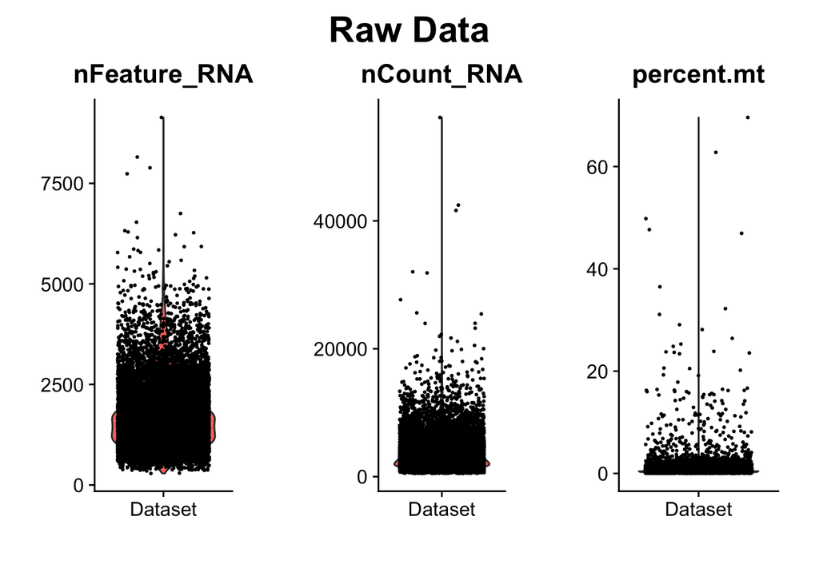

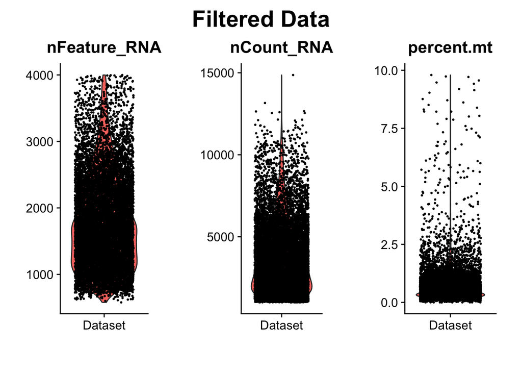

**Number of cells before filtering:** 11830 **Number of cells after filtering:** 11092 **Cells removed during filtering:** 738

## 2 Normalizing and Scaling Data

X-axis (Average Expression): How much a gene is expressed overall in all cells. Y-axis (Standardized Variance): How much the gene’s expression changes between cells.

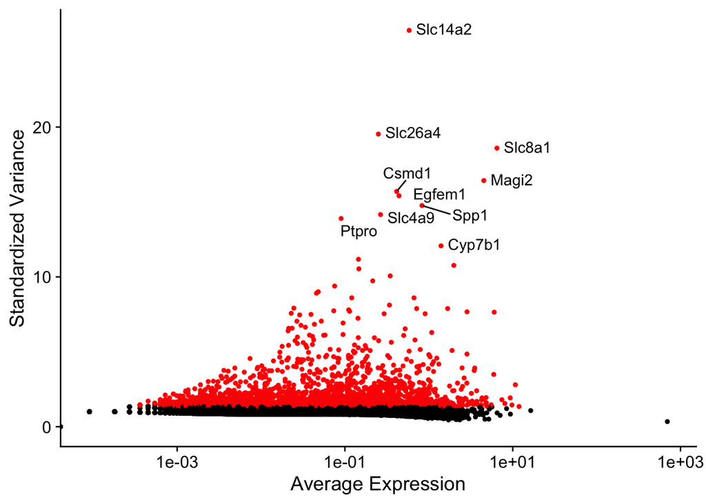

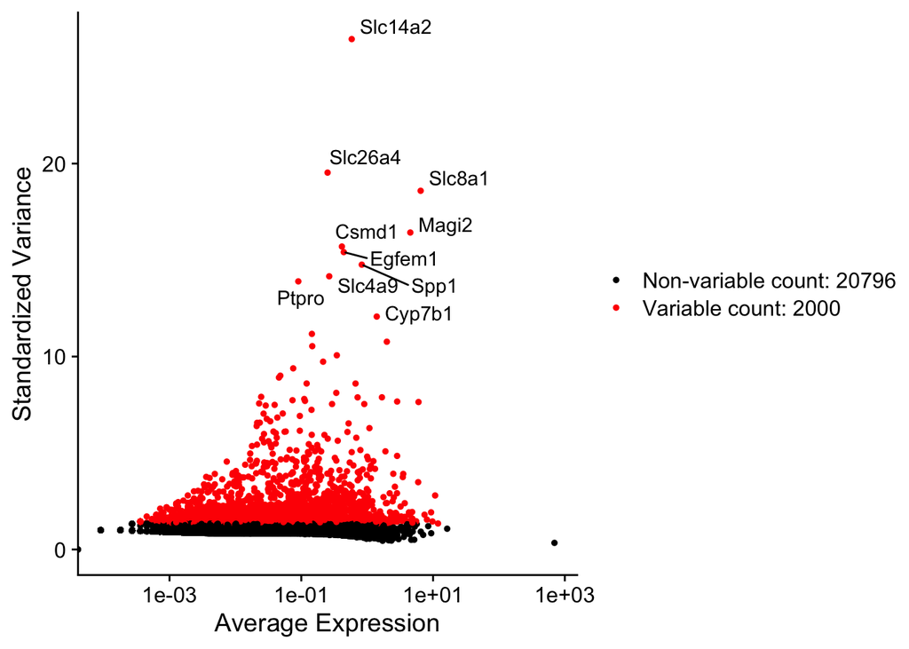

## 3 PCA

Below, in the scree bar and the elbow bar we can see that the elbow is much longer, or in other words the bars decline is smooth, this is an indicator that we have much more cell types. This shows that our dataset is indeed a whole kidney.

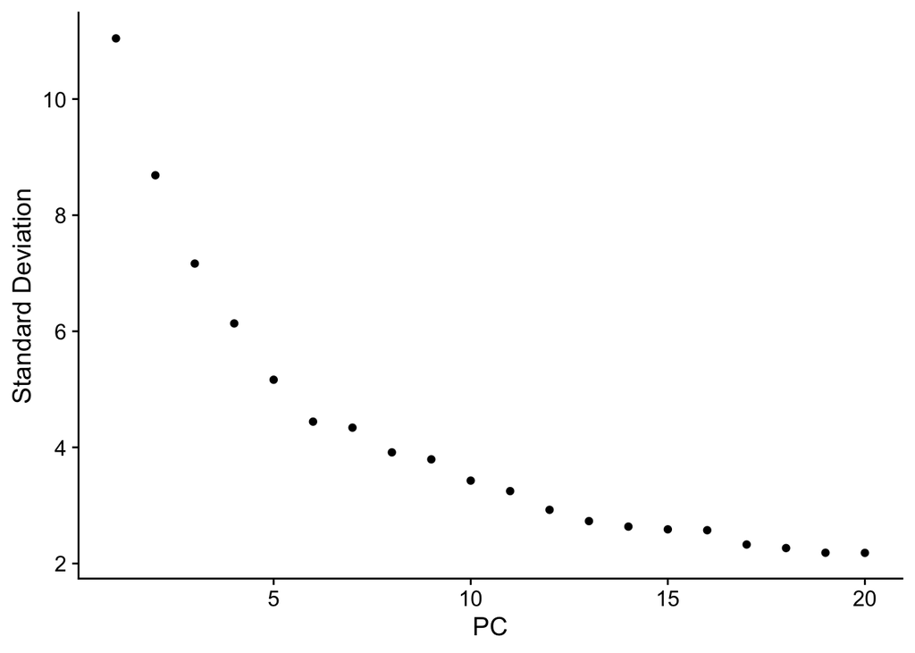

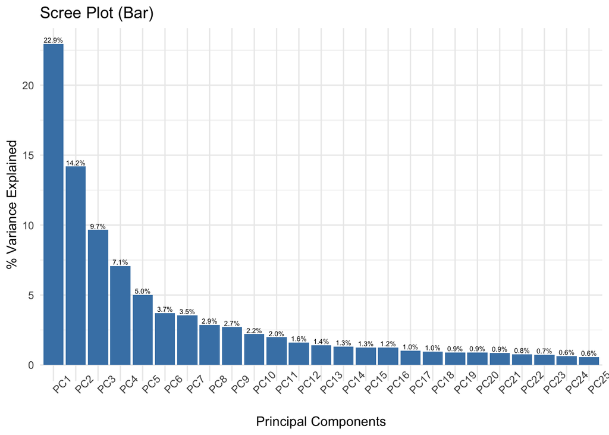

This Dimplot using PC1 and PC2 is not a good plot and indicates the need for UMAP.

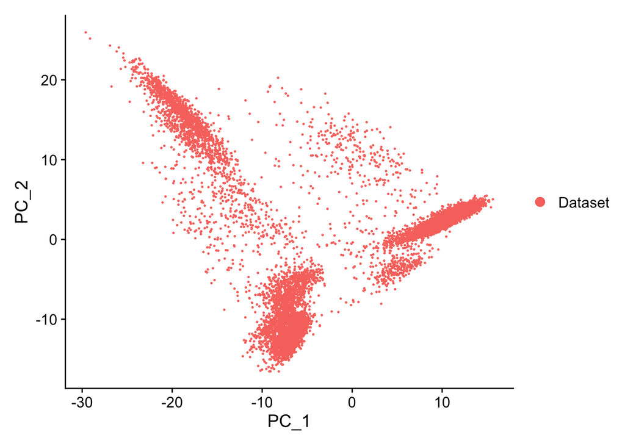

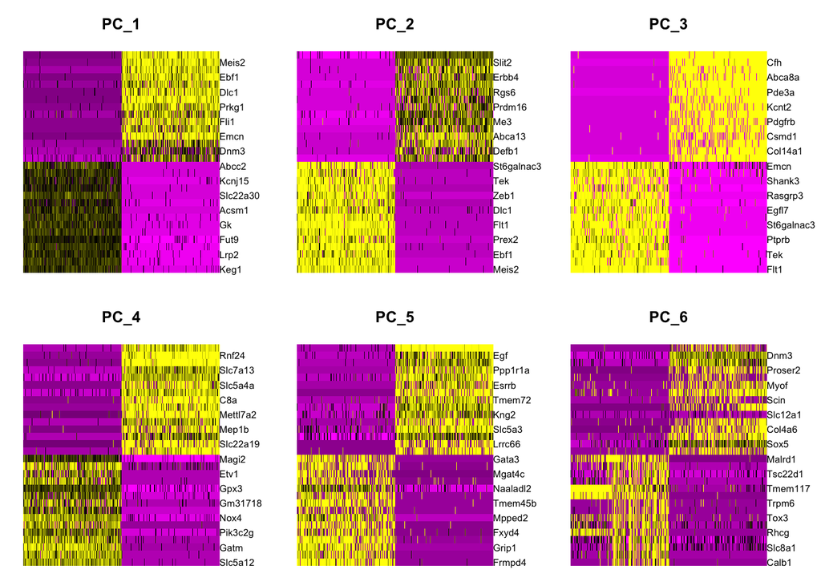

## 4 UMAP and CLuster Visualization

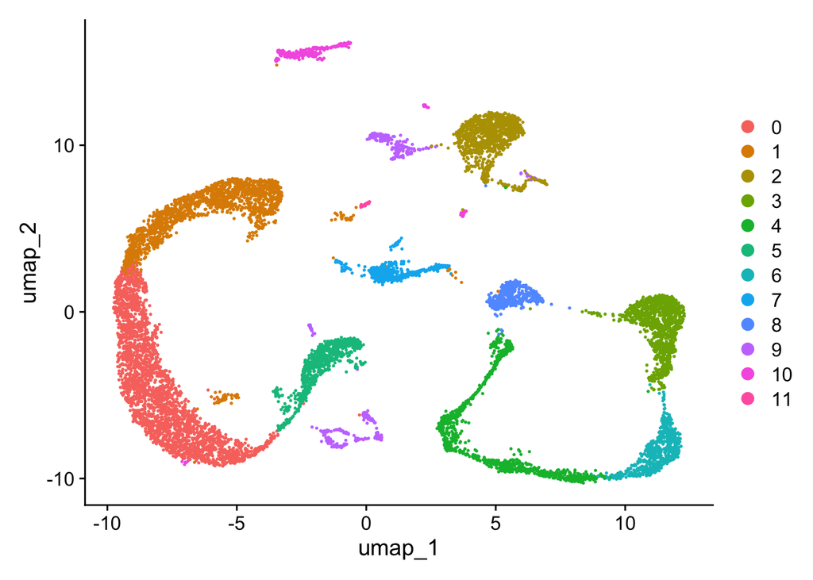

```r
Dataset_Filtered <- FindNeighbors(Dataset_Filtered, dims = 1:10)
Dataset_Filtered <- FindClusters(Dataset_Filtered, resolution = 0.1)
Dataset_Filtered <- RunUMAP(Dataset_Filtered, dims = 1:10)
DimPlot(Dataset_Filtered, reduction = "umap")
```

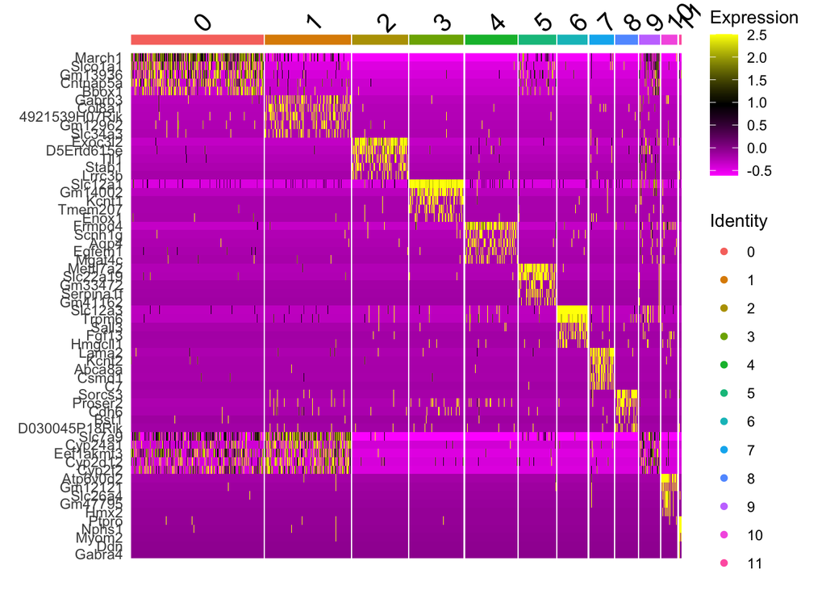

```r
Dataset_Filtered[["RNA"]] <- JoinLayers(Dataset_Filtered[["RNA"]])
Data.markers <- FindAllMarkers(Dataset_Filtered, only.pos = TRUE, min.pct = 0.25, logfc.threshold = 0.25)
Data.markers %>% group_by(cluster) %>% top_n(n = 5, wt = avg_log2FC)
top5 <- Data.markers %>% group_by(cluster) %>% top_n(5, avg_log2FC)
DoHeatmap(Dataset_Filtered, features = top5$gene)
```